# BDA507 WEEK-7 FALL 2017-18

For taste: https://selfdrivingcars.mit.edu/deeptrafficjs/

Outline:

### GENERAL REVIEW:

- Basic commands in Python
- Functions
- Libraries: Pandas, Numpy, Scipy, Matplot...
- Clustering & Classification

###### BREAK:

In the following example for loop breaks when the count value is 5. The print statement after the for loop displays the sum of first 5 elements of the tuple numbers.

```python
numbers = (1, 2, 3, 4, 5, 6, 7, 8, 9) # Declaring the tuple
num_sum = 0
count = 0
for x in numbers:
    num_sum = num_sum + x
    count = count + 1
    if count == 5:
        break
print("Sum of first ",count,"integers is: ", num_sum)
```

```
Sum of first  5 integers is:  15
```

###### CONTINUE:

The continue statement is used in a while or for loop to take the control to the top of the loop without executing the rest statements inside the loop. Here is a simple example.

In the above example, the for loop prints all the numbers from 0 to 6 except 3 and 6 as the continue statement returns the control of the loop to the top

```python
for x in range(7):
    if (x == 3 or x==6):
        continue
    print(x)
```

```
0
1
2
4
5
```

###### Errors and Exceptions:

Until now error messages haven’t been more than mentioned, but if you have tried out the examples you have probably seen some. There are (at least) two distinguishable kinds of errors: syntax errors and exceptions. https://www.tutorialspoint.com/python3/python_exceptions.htm

```python
(x, y) = (5, 0)  # Zero division error
try:
    z = x / y
except ZeroDivisionError as e:
    z = e  # representation: "<exceptions.ZeroDivisionError instance at 0x817426c>"
print(z)  # output: "integer division or modulo by zero"
```

```
division by zero
```

###### List of exceptions:

https://docs.python.org/3/tutorial/errors.html

try: You do your operations here ...................... except ExceptionI: If there is ExceptionI, then execute this block. except ExceptionII: If there is ExceptionII, then execute this block. ...................... else: If there is no exception then execute this block.

```python
#!/usr/bin/python3

# Define a function here.
def temp_convert(var):
   try:
      return int(var)
   except ValueError as Argument:
      print("The argument does not contain numbers\n", Argument)

# Call above function here.
temp_convert("xyz")
temp_convert(100000)
```

```
The argument does not contain numbers
 invalid literal for int() with base 10: 'xyz'
```

```
100000
```

##### TASK: Please explain briefly what the code below does!

```python
#!/usr/bin/python3
def functionName( level ):
   if level <1:
      raise Exception(level)
      # The code below to this would not be executed
      # if we raise the exception
   return level

try:
   l = functionName(10)
   print ("level = ",l)
except Exception as e:
   print ("error in level argument",e.args[0])
```

```
level =  10
```

##### Answer:

if argumant smaller than 1: function printed an error otherwise it write an argument.

###### ASSERTIONS:

An assertion is a sanity-check that you can turn on or turn off when you are done with your testing of the program. The easiest way to think of an assertion is to liken it to a raise-if statement (or to be more accurate, a raise-if-not statement). An expression is tested, and if the result comes up false, an exception is raised. Assertions are carried out by the assert statement, the newest keyword to Python, introduced in version 1.5. Programmers often place assertions at the start of a function to check for valid input, and after a function call to check for valid output.

```python
#!/usr/bin/python
def KelvinToFahrenheit(Temperature):
   assert((Temperature >= 0),"Colder than absolute zero!")
   return ((Temperature-273)*1.8)+32

print(KelvinToFahrenheit(273))
print(int(KelvinToFahrenheit(505.78)))
print(KelvinToFahrenheit(-5))
```

```
32.0
451
-468.40000000000003
```

```python
number = int(input('Enter a positive number:'))
# Enter a positive number:-1
assert (number > 0), 'Only positive numbers are allowed!'
```

```
Enter a positive number:5
```

###### RECURSION:

- An expression, such as a polynomial, each term of which is determined by application of a formula to preceding terms.
- A formula that generates the successive terms of a recursion.

##### TASK-1:

Use a loop-function (for or while loop) in order to give the following output regarding the user input. Let’s assume that the user has entered 5 and your code should give the outputs from 5 to 1 and prints them on the screen. 5 4 3 2 1 Finito!

```python
# Countdown example that will produce the output as follows: n, n-1, n-2, ..... 3, 2, 1, 'Finito!'
# Recursive
def countdown(n):
    if n == 0:
        print("Finito!")
    else:
        print(n)
        countdown(n-1)
countdown(5)
```

```
5
4
3
2
1
Finito!
```

```python
# Countdown example that will produce the output as follows: n, n-1, n-2, ..... 3, 2, 1, 'Finito!'
# Iterative
def countdown(n):
    i = n
    while i >= 0:
        if i == 0:
            print("Finito!")
            i = i - 1
        else:
            print(i)
            i = i - 1
countdown(5)
```

```
5
4
3
2
1
Finito!
```

##### TASK-2:

Please modify the code above to get input from the user. And your script should provide the countdown from this input until zero. You need to call the same function above.

```python
l = int(input('Enter a positive number:'))
def countdown(n):
    if n <= 0:
        print("Finito!")
    else:
        print(n)
        countdown(n-2)
countdown(l)
```

```
Enter a positive number:9
9
7
5
3
1
Finito!
```

Roughly speaking, recursion and iteration perform the same kinds of tasks: Solve a complicated task one piece at a time, and combine the results.

- Emphasis of iteration:
  - Keep repeating until a task is “done” e.g., loop counter reaches limit, linked list reaches null pointer.
- Emphasis of recursion:
  - Solve a large problem by breaking it up into smaller and smaller pieces until you can solve it; combine the results. e.g., recursive factorial function.

Which is better? No clear answer, but there are known trade-offs. “Mathematicians” often prefer recursive approach.

- Solutions often shorter, closer in spirit to abstract mathematical entity.
- Good recursive solutions may be more difficult to design and test. “Programmers”, esp. w/o college CS training, often prefer iterative solutions.
- Somehow, it seems more appealing to many.
- Control stays local to loop, less “magical”. Compare iterative to recursive versions of factorial!

##### TASK-3: FIBONACCI

Here is Fibonacci numbers: 1, 1, 2, 3, 5, 8, 13, 21, 34, 55,... Thus, a term is the sum of previous two terms. You are asked to find the nth term in Fibonacci series with iteration and recursion (two different functions).

def fibonacci_iter ... ...

def fibonacci_rec ... ...

```python
t = int(input('Enter a positive number:'))
def fibonacci_iter(t):
    i = 1
    k = 0
    while t > 1:
        y = i
        i = i+k
        k = y
        t = t-1
    print(i)

fibonacci_iter(t)
```

```
Enter a positive number:4
3
```

```python
def fibonacci_rec(n):
    if n == 1 or n == 2:
        return 1
    return fibonacci_rec(n-1) + fibonacci_rec(n-2)


m = int(input('Enter a positive number:'))

fibonacci_rec(m)
```

```
Enter a positive number:8
```

```
21
```

##### DESIGNING RECURSIVE FUNCTIONS:

A recursive function just means a function that calls itself. But there must be some occasions when the function does not call itself, or else the program will run forever, like we saw above. A base case is the part of a recursive function where it doesn't call itself. In the example above, the base case was n<=0. Designing a recursive function requires that you carefully choose a base case and make sure that every sequence of function calls eventually reaches a base case. In the next exercise, the base case has been programmed for you, but you will write the rest of the recursive function.

##### TASK-4A: FACTORIAL

You should provide two functions to calculate factorial, one with iteration and the other with recursion.

def factorial_iter: ... ...

def factorial_rec: ... ...

```python
def factorial_iter(n):
    i  = n
    while i > 1:
        n = n * (i - 1)
        i = i - 1
    return n

print(factorial_iter(5))
print(factorial_iter(2))
print(factorial_iter(0))
```

```
120
2
0
```

```python
def factorial_rec(n):
    if(n == 1):
        return 1
    elif(n == 0):
        return 0
    else:
        return n * factorial_rec(n-1)

print(factorial_rec(5))
print(factorial_rec(2))
print(factorial_rec(0))
```

```
120
2
0
```

Unscramble the lines to create a program that produces a recursive ruler-like design. For example, when n=3 the program should output the following design.

- '-'
- '--'
- '-'
- '---'
- '-'
- '--'
- '-'

##### TASK-5:

Please provide the necessary ordering to provide the output above:

- def ruler(n):
- else:
- print('-')
- if n == 1:
- ruler(n - 1)
- ruler(n - 1)
- print(n * '-')

```python
def ruler(n):
    if n == 1:
        print('-')
    else:
        ruler(n-1)
        print(n * '-')
        ruler(n-1)

ruler(3)
```

[output not shown]

#### Color Quantization using K-Means

Performs a pixel-wise Vector Quantization (VQ) of an image of the summer palace (China), reducing the number of colors required to show the image from 96,615 unique colors to 64, while preserving the overall appearance quality.

In this example, pixels are represented in a 3D-space and K-means is used to find 64 color clusters. In the image processing literature, the codebook obtained from K-means (the cluster centers) is called the color palette. Using a single byte, up to 256 colors can be addressed, whereas an RGB encoding requires 3 bytes per pixel. The GIF file format, for example, uses such a palette.

For comparison, a quantized image using a random codebook (colors picked up randomly) is also shown.

```python
print(__doc__)
import numpy as np
import matplotlib.pyplot as plt
from sklearn.cluster import KMeans
from sklearn.metrics import pairwise_distances_argmin
from sklearn.datasets import load_sample_image
from sklearn.utils import shuffle
from time import time

n_colors = 64
# n_colors = 64
```

```
Automatically created module for IPython interactive environment
```

```python
# Load the Summer Palace photo
china = load_sample_image("china.jpg")
print(china)
# Convert to floats instead of the default 8 bits integer coding. Dividing by
# 255 is important so that plt.imshow behaves works well on float data (need to
# be in the range [0-1])
china = np.array(china, dtype=np.float64) / 255

print(china)
print(china.shape)
```

[output not shown]

[output cut: 42 more lines]

[output not shown]

```python
# Load Image and transform to a 2D numpy array.
w, h, d = original_shape = tuple(china.shape)
print(w)
print(h)
print(d)
assert d == 3
image_array = np.reshape(china, (w * h, d))
print(image_array)
print("Fitting model on a small sub-sample of the data")
t0 = time()
image_array_sample = shuffle(image_array, random_state=0)[:1000]
kmeans = KMeans(n_clusters=n_colors, random_state=0).fit(image_array_sample)
print("done in %0.3fs." % (time() - t0))
```

```
427
640
3
[[ 0.68235294  0.78823529  0.90588235]
 [ 0.68235294  0.78823529  0.90588235]
 [ 0.68235294  0.78823529  0.90588235]
 ...,
 [ 0.16862745  0.19215686  0.15294118]
 [ 0.05098039  0.08235294  0.02352941]
 [ 0.05882353  0.09411765  0.02745098]]
Fitting model on a small sub-sample of the data
done in 0.214s.
```

```python
# Get labels for all points
print("Predicting color indices on the full image (k-means)")
t0 = time()
labels = kmeans.predict(image_array)
print("done in %0.3fs." % (time() - t0))
print(labels)
n_digits = len(np.unique(labels))  # the number of labels are determined with the aid of unique formula
print(n_digits)

codebook_random = shuffle(image_array, random_state=0)[:n_colors + 1]
print("Predicting color indices on the full image (random)")
t0 = time()
labels_random = pairwise_distances_argmin(codebook_random,
                                          image_array,
                                          axis=0)
print("done in %0.3fs." % (time() - t0))


def recreate_image(codebook, labels, w, h):
    """Recreate the (compressed) image from the code book & labels"""
    d = codebook.shape[1]
    image = np.zeros((w, h, d))
    label_idx = 0
    for i in range(w):
        for j in range(h):
            image[i][j] = codebook[labels[label_idx]]
            label_idx += 1
    return image
```

```
Predicting color indices on the full image (k-means)
done in 0.128s.
[62 62 62 ...,  1  6  6]
64
Predicting color indices on the full image (random)
done in 0.117s.
```

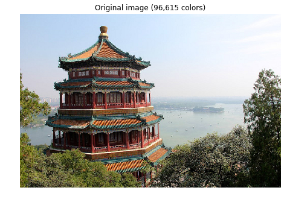

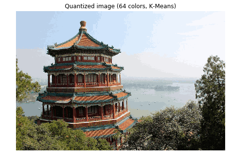

[figure not shown]

```python
# Display all results, alongside original image
plt.figure(1)
plt.clf()
ax = plt.axes([0, 0, 1, 1])
plt.axis('off')
plt.title('Original image (96,615 colors)')
plt.imshow(china)

plt.figure(2)
plt.clf()
ax = plt.axes([0, 0, 1, 1])
plt.axis('off')
plt.title('Quantized image (64 colors, K-Means)')
plt.imshow(recreate_image(kmeans.cluster_centers_, labels, w, h))

plt.figure(3)
plt.clf()
ax = plt.axes([0, 0, 1, 1])
plt.axis('off')
plt.title('Quantized image (64 colors, Random)')
plt.imshow(recreate_image(codebook_random, labels_random, w, h))
plt.show()
```

#### Classification applications on the handwritten digits data

In this example, you will see two different applications of Naive Bayesian Algorithm on the digits dataset.

```
Automatically created module for IPython interactive environment
[0 1 2 ..., 8 9 8]
dict_keys(['data', 'target', 'target_names', 'images', 'DESCR'])
Optical Recognition of Handwritten Digits Data Set
===================================================

Notes
-----
Data Set Characteristics:
    :Number of Instances: 5620
    :Number of Attributes: 64
    :Attribute Information: 8x8 image of integer pixels in the range 0..16.
    :Missing Attribute Values: None
    :Creator: E. Alpaydin (alpaydin '@' boun.edu.tr)
    :Date: July; 1998

This is a copy of the test set of the UCI ML hand-written digits datasets
http://archive.ics.uci.edu/ml/datasets/Optical+Recognition+of+Handwritten+Digits

The data set contains images of hand-written digits: 10 classes where
each class refers to a digit.

Preprocessing programs made available by NIST were used to extract
normalized bitmaps of handwritten digits from a preprinted form. From a
total of 43 people, 30 contributed to the training set and different 13
to the test set. 32x32 bitmaps are divided into nonoverlapping blocks of
4x4 and the number of on pixels are counted in each block. This generates
an input matrix of 8x8 where each element is an integer in the range
0..16. This reduces dimensionality and gives invariance to small
distortions.

For info on NIST preprocessing routines, see M. D. Garris, J. L. Blue, G.
T. Candela, D. L. Dimmick, J. Geist, P. J. Grother, S. A. Janet, and C.
L. Wilson, NIST Form-Based Handprint Recognition System, NISTIR 5469,
1994.

References
----------
  - C. Kaynak (1995) Methods of Combining Multiple Classifiers and Their
    Applications to Handwritten Digit Recognition, MSc Thesis, Institute of
    Graduate Studies in Science and Engineering, Bogazici University.
  - E. Alpaydin, C. Kaynak (1998) Cascading Classifiers, Kybernetika.
  - Ken Tang and Ponnuthurai N. Suganthan and Xi Yao and A. Kai Qin.
    Linear dimensionalityreduction using relevance weighted LDA. School of
    Electrical and Electronic Engineering Nanyang Technological University.
    2005.
  - Claudio Gentile. A New Approximate Maximal Margin Classification
    Algorithm. NIPS. 2000.
```

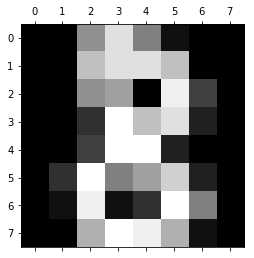

```
[[  0.   0.   5.  13.   9.   1.   0.   0.]
 [  0.   0.  13.  15.  10.  15.   5.   0.]
 [  0.   3.  15.   2.   0.  11.   8.   0.]
 [  0.   4.  12.   0.   0.   8.   8.   0.]
 [  0.   5.   8.   0.   0.   9.   8.   0.]
 [  0.   4.  11.   0.   1.  12.   7.   0.]
 [  0.   2.  14.   5.  10.  12.   0.   0.]
 [  0.   0.   6.  13.  10.   0.   0.   0.]]
```

```python
print(__doc__)

import pylab as pl
from sklearn.datasets import load_digits
from sklearn.decomposition import PCA
from time import time
import numpy as np
from sklearn import metrics
from sklearn.cluster import KMeans
from sklearn.preprocessing import scale
########################################################################################################################
##################################### GETTING THE DATA & PREPARATIONS ##################################################
########################################################################################################################

np.random.seed(42)
digits = load_digits()
# the whole dataset with the labels and other information are extracted
data = scale(digits.data)
# the data is scaled with the use of z-score
n_samples, n_features = data.shape
# the no. of samples and no. of features are determined with the help of shape
n_digits = len(np.unique(digits.target))
# the number of labels are determined with the aid of unique formula
labels = digits.target
# get the ground-truth labels into the labels

print(labels)
print(digits.keys())  # this command will provide you the key elements in this dataset
print(digits.DESCR)  # to get the descriptive information about this dataset

pl.gray()
pl.matshow(digits.images[8])
pl.show()
print(digits.images[0])
```

```python
from sklearn.model_selection import train_test_split
# some documents still include the cross-validation option but it no more exists
# in version 18.0
from sklearn.naive_bayes import GaussianNB
from sklearn.metrics import confusion_matrix
from sklearn.metrics import accuracy_score
import pylab as plt
y = digits.target
X = digits.data
X_train, X_test, y_train, y_test = train_test_split(X, y, test_size=0.3, random_state=10)
```

```python
gnb = GaussianNB()
fit2 = gnb.fit(X_train, y_train)
predicted = fit2.predict(X_test)
print(confusion_matrix(y_test, predicted))
print(accuracy_score(y_test, predicted))
# the use of another function for calculating the accuracy
# (correct_predictions / all_predictions)
print(accuracy_score(y_test, predicted, normalize=False))
# the number of correct predictions
print(len(predicted))
# number of all of the predictions


import pickle
filename = 'finalized_model.csv'
pickle.dump(fit2, open(filename, 'wb'))

loaded_model = pickle.load(open(filename, 'rb'))
result = loaded_model.score(X_test, y_test)
print(result)
```

```
[[49  1  0  0  1  0  0  0  0  0]
 [ 0 53  1  0  0  0  0  0  3  0]
 [ 0  8 27  8  0  0  0  0 12  0]
 [ 0  0  0 51  0  0  0  1  3  1]
 [ 0  8  0  0 39  1  0  2  1  0]
 [ 0  0  0  1  0 46  0  3  1  0]
 [ 0  1  1  0  0  0 53  0  0  0]
 [ 0  0  0  0  1  0  0 59  0  0]
 [ 0 13  0  1  0  3  0  2 31  0]
 [ 0  2  0  7  0  1  1  9  3 31]]
0.812962962963
439
540
0.812962962963
```

```python
gnb = GaussianNB()
fit2 = gnb.fit(X, y)
predictedx = fit2.predict(X)
print(confusion_matrix(y, predictedx))
print(accuracy_score(y, predictedx))
# the use of another function for calculating the accuracy
# (correct_predictions / all_predictions)
print(accuracy_score(y, predictedx, normalize=False))
# the number of correct predictions
print(len(predictedx))  # number of all of the predictions

unique_y, counts_y = np.unique(y, return_counts=True)
print(unique_y, counts_y)
unique_p, counts_p = np.unique(predictedx, return_counts=True)
print(unique_p, counts_p)
print((predictedx == 0).sum())
```

```
[[176   0   0   0   1   0   0   1   0   0]
 [  0 154   0   0   0   0   3   5  14   6]
 [  0  13 113   0   0   1   1   0  49   0]
 [  0   2   2 145   0   6   0   7  20   1]
 [  1   1   0   0 152   1   2  21   3   0]
 [  0   0   0   3   0 169   1   6   2   1]
 [  0   1   0   0   0   1 179   0   0   0]
 [  0   0   0   0   1   1   0 177   0   0]
 [  0   8   0   1   0   3   0  12 150   0]
 [  1   6   0   5   1   3   0  17  20 127]]
0.858096828047
1542
1797
[0 1 2 3 4 5 6 7 8 9] [178 182 177 183 181 182 181 179 174 180]
[0 1 2 3 4 5 6 7 8 9] [178 185 115 154 155 185 186 246 258 135]
178
```